# R implementation of Mapper

[figure not shown]

[figure not shown]

The `Mapper` package provides an [R](https://www.r-project.org/) implementation of the *Mapper* framework (see 1). The package includes:

[figure not shown]

- Efficient implementation of *Mapper* components using [Rcpp](https://cran.r-project.org/web/packages/Rcpp/index.html)
- Extendable [R6 generators](https://github.com/r-lib/R6) for *Mappers* components
- Practical default filters, covers, and other settings for those unfamiliar with *Mapper*
- Composable API via [method chaining](https://adv-r.hadley.nz/r6.html#method-chaining)
- Pre-configured tools for visualizing and interacting with *mappers*

The package is designed to make modifying or extending the *Mapper* method simple and efficient, without limiting its generality.

### Getting started

#### Installation

Install the `Mapper` package from github as follows:

```r
require("devtools")
devtools::install_github("peekxc/mapper")
```

A CRAN release is planned for the near future.

#### Creating a complex

*Mapper* takes as input a point cloud $X$ and a reference map $f : X \to Z$, and returns a topological summary of $X$ expressed via a cover equipped on the codomain of the map. For example, consider a point cloud sampled from an ‘eight-curve’ in $\mathbb{R}^2$:

$$g(t) = [\cos(t), \sin(t)\cos(t)],\; t \in \Big(-\frac{1}{2}\pi, \frac{3}{2}\pi\Big)$$
In the example below, the data set $X$ is created from equally spaced samples over $t$, and the map chosen is simply the $x$-coordinate of the shape, i.e. $f(X) = Z = x_1$.

[figure not shown]

```r
t <- seq(-0.5*pi, (3/2)*pi, length.out = 100) + runif(100, max = 0.01)
eight <- cbind(x1=cos(t), x2=sin(t)*cos(t))
f_x <- matrix(cos(t))

## Use a rainbow palette
rbw_col <- rainbow(length(f_x), start = 0, end = 4/6)
col <- rbw_col[cut(f_x, length(f_x), labels = FALSE)]

## View the data along with the mapping
layout(matrix(1:2, nrow = 1))
plot(eight, pch = 20, col = col, main = expression(X %subset% R^2))
stripchart(f_x, pch = "|", main = expression(f(X) %subset% R))
points(cbind(f_x, 1), pch = "|", col = col, cex = 2)
```

Below is a illustrative example of how one may go about constructing a *mapper*.

```r
m <- MapperRef$new(X = eight)$
  use_filter(filter= f_x)$
  use_cover(cover = "fixed interval", number_intervals = 5, percent_overlap = 20)$
  use_clustering_algorithm(cl = "single")$
  construct_k_skeleton(k = 1L)
print(m)
```

```
## Mapper construction with (7, 8) (0, 1)-simplices
## Fixed Interval Cover: (number intervals = [5], percent overlap = [20]%)
```

There are multiple options one may use to visualize **mapper**. A default plotting method is available using an `igraph` determined layout:

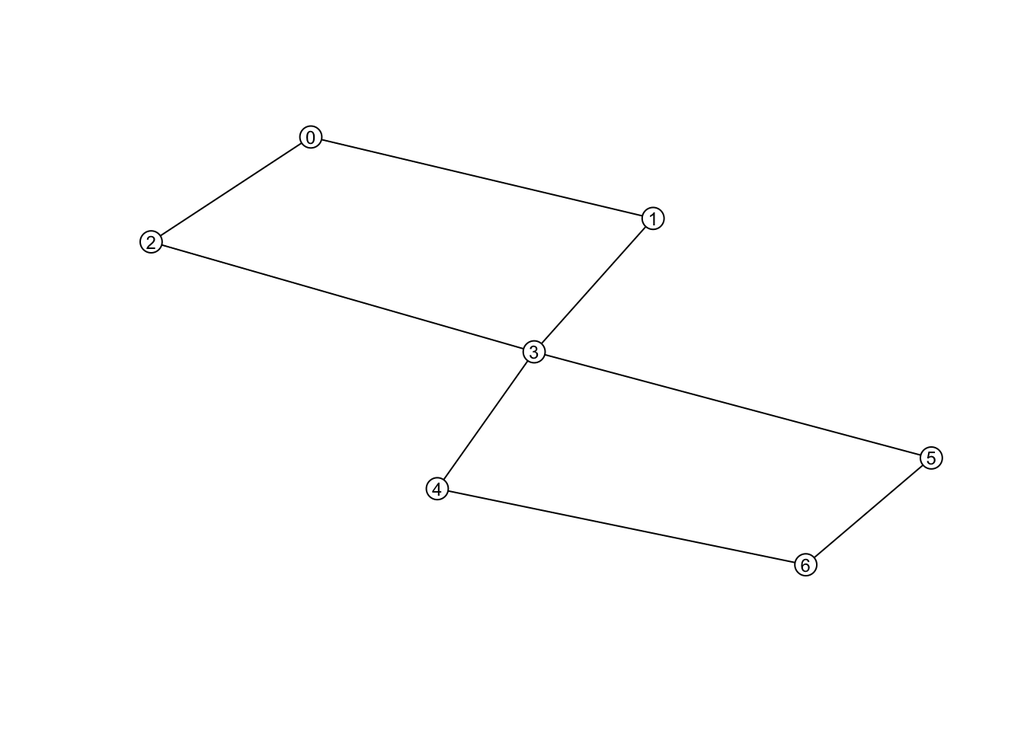

```r
plot(m$simplicial_complex)
```

For other visualization options, see below.

#### Customizing Mapper

Almost any component of the Mapper method can be customized.

Want to change the metric? Pass the name of any proximity measure used in the [proxy](https://cran.r-project.org/web/packages/proxy/index.html) package.

```r
## See ?proxy::pr_DB for more details.
m$use_distance_measure("manhattan") ## This is stored as m$measure
```

Prefer a different [linkage criteria](https://en.wikipedia.org/wiki/Hierarchical_clustering#Linkage_criteria) to cluster with? Any of the criteria used by [hclust](https://stat.ethz.ch/R-manual/R-devel/library/stats/html/hclust.html) can be swapped in.

```r
m$use_clustering_algorithm(cl = "average")
```

Or, just replace the clustering algorithm entirely by supplying a function.

```r
## If using a custom metric, just compute the distance matrix
## pid := open set index
## idx := point indices in the preimage of the open set indexed by 'pid'
m$use_clustering_algorithm(cl = function(pid, idx){
  dist_x <- dist(self$X(idx), method = self$measure)
  hc <- hclust(dist_x, method = "average")
  eps <- cutoff_first_threshold(hc)
  cutree(hc, h = eps)
})
```

If you prefer a different covering, just assign a valid object inheriting from `CoverRef`.

```r
m$use_cover(cover="fixed interval", number_intervals = 10L, percent_overlap = 50)
```

A list of available covering methods, their correspondings parameters, and their generators can be printed as follows:

```r
covers_available()
```

```
## Typename:                    Generator:                         Parameters:
##  fixed interval               FixedIntervalCover                 number_intervals, percent_overlap
##  restrained interval          RestrainedIntervalCover            number_intervals, percent_overlap
##  adaptive                     AdaptiveCover                      number_intervals, percent_overlap, quantile_method
##  ball                         BallCover                          epsilon
```

Alternatively, you can create your own cover. See the article on how to make custom cover.

Constructing the simplicial complex requires applying the *pullback* operation prior to constructing nerve. The pullback applies the clustering algorithm to subsets of the data given by the cover, which decomposes the data set into connected components. In Mapper, these connected components are represented as vertices. To view the mapping from open sets to vertices, use the `pullback` member:

```r
m$construct_pullback()
str(m$pullback)
```

```
## List of 10
##  $ (1) : num 0
##  $ (2) : num [1:2] 1 2
##  $ (3) : num [1:2] 3 4
##  $ (4) : num 5
##  $ (5) : num 6
##  $ (6) : num 7
##  $ (7) : num 8
##  $ (8) : num [1:2] 9 10
##  $ (9) : num [1:2] 11 12
##  $ (10): num 13
```

The simplicial complex is available via the `$simplicial_complex` member, and the points in contained in each vertex is available via the `$vertices` member.

```r
m$simplicial_complex
```

```
## Simplex Tree with (14) (0)-simplices
```

The complex is stored in a Simplex Tree (see 2), and the vertices are stored are stored as a named list, where each name corresponds to the 0-simplex in the simplicial complex, and each value denotes a vector of the points indices that comprise the connected component.

```r
sapply(m$vertices, length)
```

```
##  0  1  2  3  4  5  6  7  8  9 10 11 12 13
## 25 10  9  7  8 13 14 14 13  8  7  9 10 25
```

Once you’re satisfied with the clustering, you can construct the nerve by considering the $k+1$-fold non-empty intersections between the sets in the pullback. It’s common to restrict the degree of the intersections considered, e.g. to ensure the *mapper* is a graph, use $k=1$.

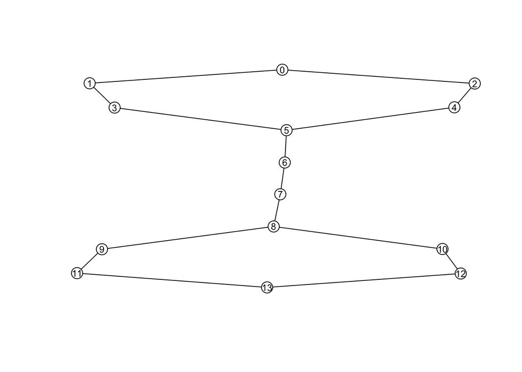

```r
m$construct_nerve(k = 1L)
plot(m$simplicial_complex)
```

### Visualizing the **mapper**

To get a quick overview of what the **mapper** looks like, you can use the default plotting method above given by the [simplextree package](https://github.com/peekxc/simplextree).

Alternatively, the $1$-skeleton can be exported to any of the usual graph-type data structures.

```r
m$simplicial_complex$as_adjacency_matrix()
m$simplicial_complex$as_adjacency_list()
m$simplicial_complex$as_edge_list()
```

These graph data-structures can then be converted to [igraph](https://igraph.org/r/) objects and customized however needed. A default export option is available:

[figure not shown]

```r
plot(m$as_igraph())
```

One of the standard way of visualizing **mappers** is to size the vertices logarithmically according to how many points they have in them and colored based on the mean value of the points $f$ values. Each vertex is given a label of the form “x:y” where ‘x’ denotes the vertex id, and ‘y’ denotes the number of points in the vertex.

For more interactive options, consider the (experimental) pixiplex package.

```r
# devtools::install_github("peekxc/pixiplex")
library("pixiplex")
plot(m$as_pixiplex())
```

[interactive chart not shown]

## References

1. Singh, Gurjeet, Facundo Mémoli, and Gunnar E. Carlsson. “Topological methods for the analysis of high dimensional data sets and 3d object recognition.” SPBG. 2007.

2. Boissonnat, Jean-Daniel, and Clément Maria. “The simplex tree: An efficient data structure for general simplicial complexes.” Algorithmica 70.3 (2014): 406-427.